# R Notebook

### Directional change in community composition based on treatment identity

### Background

- Global changes related to resource limtation are a well-studied phenomenon in ecology. Chronic nutrient enrichment, for example, is often expected to drive changes in community composition by altering competitive interactions.
- Many experiments that explore global change factors do so on relatively short timescales. However, these effects may not hold constant over time.
- Interactions between multiple drivers of resource limitation may be expected to produce nonlinear shifts in community dynamics that may contrast with those observed in short-term manipulative experiments.
- In particular, the strength of directional change in community composition is expected to be dependent on the nature of artificial resource enrichment (press vs. pulse) + other sources of environmental heterogeneity in a given system (e.g. Smith et al. 2009).
- When chronic nutrient deposition affects the primary axis of resource competition in community assembly, consistent directional change in community composition may be expected.
- However, when nutrient deposition interacts strongly with other drivers of resource limitation (such as normal environmental fluctuations, or extreme events, such as drought), community change may be strongly nonlinear/idiosyncratic

**Study sites**

NutNet has the advantage of (relatively) long-term datasets of community change across a number of sites in the United States. Within both California and across the Great Plains, there are sites containing nutrient enrichment treatments across a gradient of climatic conditions (precipitation/temperature)

- California Nutrient Network sites
- American perennial grassland sites? Konza/CdrCreek/etc.

**Some expectations:** * All sites show changes in ANPP as a function of Nutrient enrichment + climate * Sites with the greatest sensitivity to climate in ANPP will show the least directional change * Sites with an annual life history (greater sensitivity / variability) will show less directional change * In all sites, nutrient enrichment will cause segregation of communities with respect to one another over time * Strength of nutrient enrichment in explaining multivariate dissimilaritiy between communities will depend on climate sensitivity

**Steps:**

1. Present characterization of site ANPP, climate regime, nutrient enrichment effects **(Siddharth, you have this data readily available?)**
2. Evaluate community directional change in response to nutrient enrichment over time.
3. Run ordination of multivariate community composition
4. PermDISP analysis of increasing dispersion over time
5. Evaluate significance of nutrient identity factors on community variance (CAP may be the best choice)

### Constructing estimates of change in abundance-weighted diversity

The first analysis I wanted to conduct was to see if there’s a general trend in abundance-weighted diversity in these sites. I think of this as being the classic response to nutrient enrichment – a decrease in diversity that saturates over time as added nutrients no longer become limiting.

However, it doesn’t seem like there’s a consistent pattern across sites. In general, diversity is all over the place – the signal of nutrient enrichment isn’t very strong.

Note: In these figures, I’m using an exponentiated diversity index (sometimes referred to as Hill numbers). I’m not sure how familiar other folks are with this metric, but it’s very similar to Shannon diversity, with some advantages when comparing sites with big differences in total species richness.

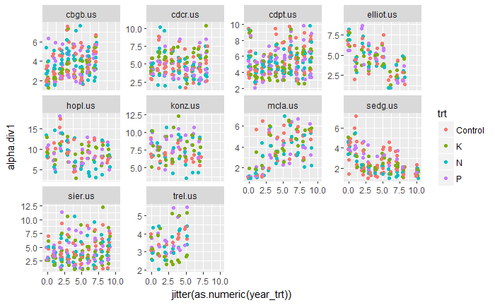

I was a little surprised by this result, so double-checked the shannon diversity richness values that are provided in the dropbox. The result seems about the same:

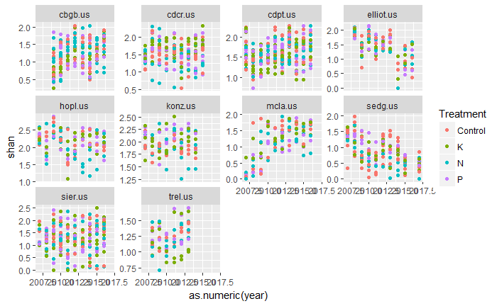

### Conducting analysis of temporal change

If there isn’t a great story associated wih diversity change, I think a focus on productivity and compositional change would be more compelling. From when we last talked about your work, I remember you talking about a project exploring the relationship between aridity index and the interaction between precipitation, temperature, and nutrient enrichment.

I think it would be really interesting to provide some context to compositional changes we might see. Comparing the relative strength of climate and nutrient enrichment effects might give us a sense of what resources are limiting in this system - if more arid systems experience greater influence of temperature and precipitation, we might anticipate that community change won’t follow a consistent directional trend, but fluctuate with seasonal variation.

My thought on how to incorporate this into analysis would be a relatively surface-level characterization, perhaps just reporting something like aridity index, MAT, and MAP for each site. I wouldn’t want to overlap with what you’ve been working on, but think this would be an opportunity to support our analysis with characterization of site resource limitation.

### Conducting analysis of temporal change

I think there are two key contrasts to be made in temporal analysis: 1. Annual vs perennially dominated sites.  
2. Degree of climatic vs fertilization resource limitation.

Hypothesis: 1. Perenially-dominated sites will show stronger patterns of directional community change in response to nutrient enrichment. 2. Less arid sites will show strong patterns of directional community change in response to nutrient enrichment.

As a first stab at this analysis, I used a modified version of the “rate_change_interval()” from the Codyn package. Rather than Euclidean distance, I opted for Bray-Curtis distance and a sqrt() transformed species matrix to reduce the influence of dominants. I don’t see any immediate issues with this approach, and it keeps analysis consistent with multivariate approaches (see next section).

In the following graphs, colored lines represent simple linear models to different treatments, faceted by site. Individual points reflect Bray-Curtis dissimilarity on the Y-axis and temporal lag on the X. Note: these treatments only focus on three treatments; N, P, and K.

From these figures, there seems to be a detectable N effect, *but only for perennial grassland sites*! Directional change is more or less the same among treatments in California.

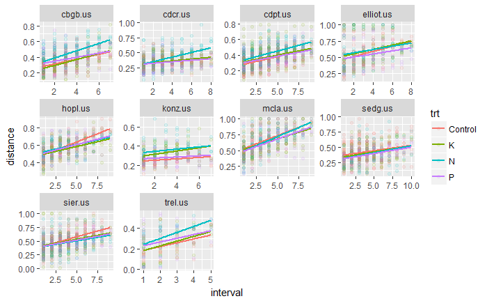

```
Data: temp_ratechange_bray[temp_ratechange_bray$trt %in% trts, ]
Models:
m2: distance ~ interval + (1 | site_code) + (1 | site_code:block)
m1: distance ~ interval + interval:trt + (1 | site_code) + (1 | site_code:block)
   Df     AIC     BIC logLik deviance  Chisq Chi Df Pr(>Chisq)
m2  5 -6851.6 -6818.2 3430.8  -6861.6
m1  8 -6914.1 -6860.6 3465.1  -6930.1 68.496      3  8.961e-15 ***
---
Signif. codes:  0 *** 0.001 ** 0.01 * 0.05 . 0.1   1
Linear mixed model fit by maximum likelihood  ['lmerMod']
Formula: distance ~ interval + interval:trt + (1 | site_code) + (1 | site_code:block)
   Data: temp_ratechange_bray[temp_ratechange_bray$trt %in% trts, ]

     AIC      BIC   logLik deviance df.resid
 -6914.1  -6860.6   3465.1  -6930.1     5961

Scaled residuals:
    Min      1Q  Median      3Q     Max
-3.4432 -0.6359 -0.0675  0.5718  4.4292

Random effects:
 Groups          Name        Variance  Std.Dev.
 site_code:block (Intercept) 0.0006942 0.02635
 site_code       (Intercept) 0.0123215 0.11100
 Residual                    0.0179837 0.13410
Number of obs: 5969, groups:  site_code:block, 40; site_code, 10

Fixed effects:
               Estimate Std. Error t value
(Intercept)    0.341089   0.035535   9.599
interval       0.027998   0.001093  25.604
interval:trtK -0.001789   0.001200  -1.491
interval:trtN  0.005383   0.001204   4.472
interval:trtP -0.004539   0.001205  -3.767

Correlation of Fixed Effects:
            (Intr) intrvl intr:K intr:N
interval    -0.060
intrvl:trtK  0.000 -0.521
intrvl:trtN -0.001 -0.518  0.475
intrvl:trtP  0.000 -0.518  0.475  0.473
```

### Ordination-based methods

The above analysis is neat, but only presents a limited scope of comparison. While we can tell how different a given plot is to itself in a previous year, community distance per time interval doesn’t tell us if these changes occur in a consistent manner. For all we know, the average nutrient enriched community over this given time period could be the same as the control, but its variability is greater.

To supplement, I think some ordination based analysis of community variation over time will allow us to compare: - How different communities in a given site are from one another. (Even if there is no difference in rate of change, are they moving in different directions?) Do different nutrients move communities in different directions? Do these changes increase over time? - How closely are sites clustering over time? Does interannual variation (attributed to climate) or nutrient enrichment effect better predict compositional differences?

This has two steps:

1. Quantifying dispersion over time (permDISP in Vegan)
2. Partitioning community variation due to nutrient identity and year.

As an illustration, I repeated this analysis for two sites - McLaughlin and Cedar Creek.

In the first figure for each, I’ve got a couple ordination plots that show overall site dispersion, grouped either by year or by treatment.

In the second, I’ve got some output for a CAP constrained ordination analysis, along with the output of the varpart() variance partitioning function (related to RDA).

In all cases, I’ve square root transformed the data to dampen some of the noise. Without this step, dominant species exert a little too much control to create distinct patterns, and I expect that precision of visual estimation goes down at higher %cover values. All distance measures are Bray-Curtis, but this can also be changed.

The general pattern I see here is that McLaughlin shows a stronger trend of increasing dispersion through time, but a much weaker signal of nutrient enrichment on the overall pattern. Cedar Creek, however, shows to opposite - slower change in dispersion through time, but a stronger nutrient enrichment signal overall.

I’d suggest playing around with this, if you’d like. This analysis is pretty surface level and doesn’t do a great job accounting for blocking, etc., but may hint at some interesting patterns.

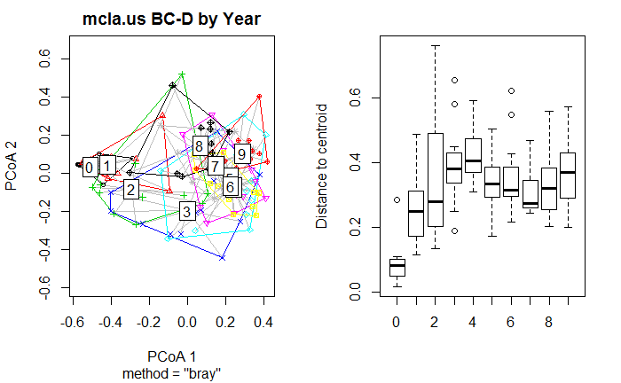

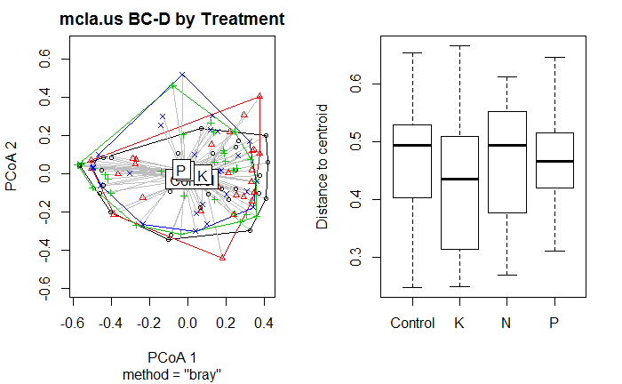

```r
cap.full <- capscale(sp.mat ~ trt * as.numeric(year_trt) + as.factor(block),
         env.mat,
         distance = distmethod)
cap.full
```

```
Call: capscale(formula = sp.mat ~ trt * as.numeric(year_trt) + as.factor(block), data = env.mat, distance =
distmethod)

              Inertia Proportion Eigenvals Rank
Total          30.750      1.000    39.897
Constrained    10.886      0.354    11.424   11
Unconstrained  19.864      0.646    28.473   71
Imaginary                           -9.147  108
Inertia is squared Bray distance

Eigenvalues for constrained axes:
 CAP1  CAP2  CAP3  CAP4  CAP5  CAP6  CAP7  CAP8  CAP9 CAP10 CAP11
4.460 2.638 1.643 0.789 0.611 0.458 0.346 0.245 0.100 0.082 0.052

Eigenvalues for unconstrained axes:
 MDS1  MDS2  MDS3  MDS4  MDS5  MDS6  MDS7  MDS8
5.429 3.584 1.649 1.609 1.383 1.215 1.048 0.941
(Showed only 8 of all 71 unconstrained eigenvalues)
```

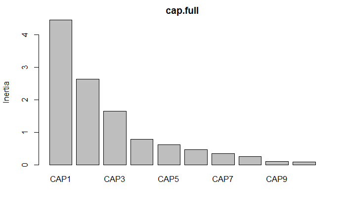

```r
screeplot(cap.full)
```

```r
varpart(sp.mat, ~ trt + as.factor(block), ~ year_trt, data = env.mat)
```

```
Partition of variance in RDA

Call: varpart(Y = sp.mat, X = ~trt + as.factor(block), ~year_trt, data = env.mat)

Explanatory tables:
X1:  ~trt + as.factor(block)
X2:  ~year_trt

No. of explanatory tables: 2
Total variation (SS): 8272.4
            Variance: 46.214
No. of observations: 180

Partition table:
                     Df R.squared Adj.R.squared Testable
[a+b] = X1            7   0.26237       0.23235     TRUE
[b+c] = X2            8   0.08313       0.04023     TRUE
[a+b+c] = X1+X2      15   0.34549       0.28563     TRUE
Individual fractions
[a] = X1|X2           7                 0.24540     TRUE
[b]                   0                -0.01305    FALSE
[c] = X2|X1           8                 0.05328     TRUE
[d] = Residuals                         0.71437    FALSE
---
Use function rda to test significance of fractions of interest
```

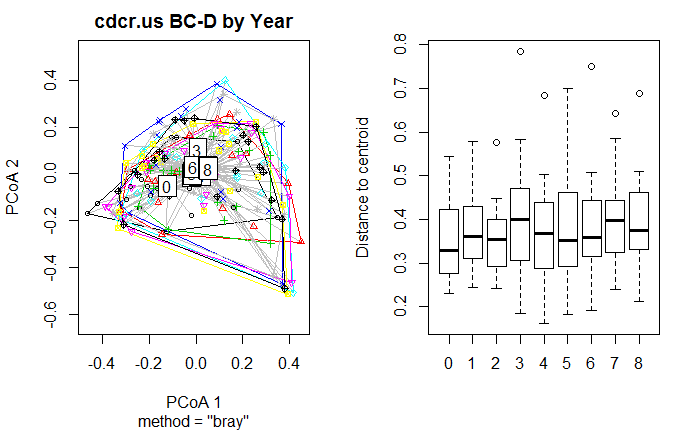

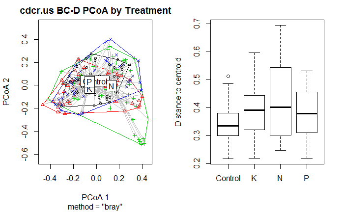

```r
anova(cap.full)
```

[output not shown]